# Tips for building a personal website using AI

A practical guide for researchers

Jihye Han

November 5, 2026

## A website that helps people find your work

- **Who are you?** Your role, affiliation, and research focus.
- **What do you study?** Questions people outside your specialty can understand.
- **Where is the evidence?** Publications and your CV.
- **How can someone reach you?** Email and professional profiles.

Today: **create with AI**, then **maintain it yourself**.

## www.jihyehan.com

[figure not shown]

**A few deliberate choices**

- Separate research, publications, and media pages
- CV access from the main navigation
- Email, Scholar, and LinkedIn links
- Navy text, teal accents, generous space

[Visit the website](https://jihyehan.com)

## Part 1: creating the website

| Step | Your job | AI’s job |
| --- | --- | --- |
| 1. Prepare | Supply verified content | Identify missing fields |
| 2. Specify | Choose pages and visual style | Build an editable first draft |
| 3. Review | Check facts and try every link | Fix specific problems |
| 4. Publish | Own the account and domain | Document the build process |

**Tips.** Ask for maintainable files and an editing guide in the first or final prompt.

## The content packet

**Prepare**

- Short bio and affiliation (for cover page)
- Public CV and a headshot (for cover or a separate CV page)
- 2–4 research questions (optional, for “Research” page)
- Verified citations and DOI links (for publication page)

**Decide**

- Optional sections
- Contact and profile links
- Colors, type, and example layouts

## A prompt that specifies the result

> Build a professional academic website for a PhD student using the attached verified content. Create Home, Research, Publications, Media, and CV pages. Use charcoal `#292524`, terracotta `#9A3412`, and an ivory `#FFFBF5` background. Use sans-serif headings, a left sidebar on desktop, and a top menu on mobile.

> Include DOI links, topic filters linked from research questions, and accessible navigation. Keep publication records in one editable data file. Do not invent facts. Flag missing information.

> Deliver the source files, preview/build commands, GitHub Pages instructions, and a file-by-file editing guide. Show me how to add one paper and replace my CV without AI.

**Tips.** Use the full copy-and-paste prompt in the appendix.

## Useful features (optional)

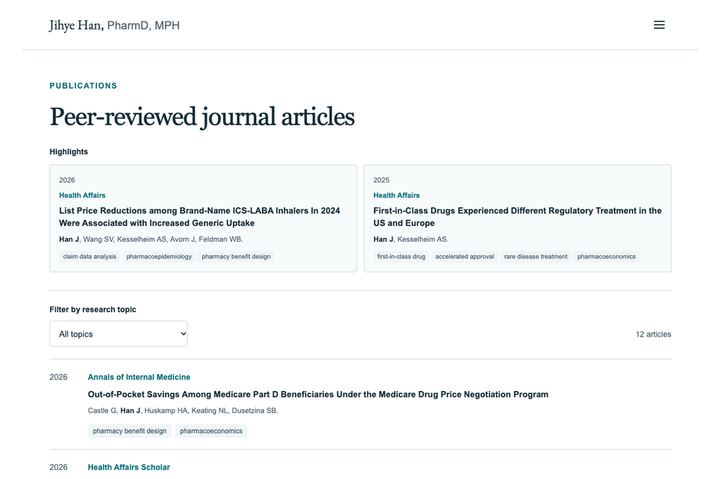

- **DOI links:** article titles open the published paper.
- **Topic links:** a research keyword opens the matching papers.
- **Filtering:** clearing the filter restores all papers.

## Publishing and an optional domain

**GitHub stores the project. GitHub Pages serves the built website.**

1. Create your own `USERNAME.github.io` repository.
2. Run `npm run build`, then publish the generated `docs/` folder from `main`.
3. Check the free GitHub Pages address.
4. Optional: buy a domain through GoDaddy and connect it using DNS.

**Tips.** Ask AI for step-by-step instructions to verify domain ownership, connect it in GitHub Pages, add the DNS records, and enable HTTPS.

## Part 2: maintaining the website yourself

| What changes? | Where you edit in this site |
| --- | --- |
| Bio, role, contact links | `app/page.tsx` |
| Research questions | `app/research/page.tsx` |
| Publication records | `app/publications.json` |
| Media coverage | `app/media/page.tsx` |
| CV PDF and headshot | `public/` |
| Colors; shared metadata and footer | `app/globals.css`; `app/layout.tsx` |

**Build = turn your edited files into website files.** In RStudio, use the **Terminal** tab beside Console. Go to the folder containing `package.json`, then run:

```bash
npm run build
```

This generates `docs/` on your computer. Commit and push those files to publish them.

**Tips.** These are terminal commands, not R code. Node.js/npm must be installed. The next build overwrites direct edits to `docs/`.

## New publications

```json
{
  "id": 13,
  "authors": "YOUR-NAME, COAUTHOR-NAME",
  "title": "YOUR ARTICLE TITLE",
  "journal": "YOUR JOURNAL",
  "year": "2026",
  "doi": "REPLACE_WITH_VERIFIED_DOI",
  "topics": ["health equity"]
}
```

**Tips.** Add the record to `app/publications.json` with a unique ID. Separate it from the next record with a comma.

## CV replacement

1. Export a new, public version of your CV as PDF.
2. Replace `public/YOUR-NAME-CV.pdf` using the **same filename**.
3. Update the footer date in `app/layout.tsx`.
4. Preview the site and open the PDF from each CV link.

**Tips.** Keep the same PDF filename so existing CV links continue to work.

## The update routine: preview your changes

1. Open RStudio’s **Terminal** tab. Use `cd "PATH/TO/YOUR-WEBSITE"` to enter the folder containing `package.json`. Before editing, run:

```bash
git status
git pull --ff-only
npm run dev
```

2. Open the **local URL printed in the terminal** in your browser, for example `http://localhost:3000`. Keep the terminal running.
3. Edit a source file in RStudio or another text editor and **save it**. Return to the browser and refresh. Open the changed page and try its links or CV download.
4. When the change looks right, click inside the **Terminal tab** and press **Ctrl+C** to stop the preview.

**Tips.** The local preview is visible on your computer. Follow the next slide to publish it. Pull only when `git status` shows no unfinished changes.

## The update routine: build and publish

1. In the same terminal, run these commands **one at a time** for a publication update:

```bash
npm run lint
npm run build
git diff -- app/publications.json
git add app/publications.json docs
git commit -m "Add new publication"
git push
```

2. **Lint** checks the code; **build** generates `docs/`. Continue after both succeed. **Diff** shows your edits; **add** selects files; **commit** saves a version; **push** sends it to GitHub.
3. On GitHub, open the repository’s **Actions** tab. Wait for the Pages deployment to succeed. Open `https://USERNAME.github.io` or your custom domain, refresh, and check the updated page.

**Tips.** For other updates, replace `app/publications.json` with the source files you changed. Include `docs/` so the website files reach GitHub too.

## Resources and discussion

**Your first independent update:** replace a CV or add one publication, preview it, and publish it.

[GitHub resource folder](https://github.com/jihyehan-research/jihyehan-research.github.io/tree/main/resources/ai-personal-website)

Open the step-by-step guide · Jump to the appendix

**Questions and discussion: up to 10 minutes**

# Step-by-step coding guide

Take-home appendix. Also available as a continuous reading guide.

## A1. Setup and terms

| Term | Meaning here |
| --- | --- |
| Repository | The project folder plus its version history on GitHub |
| Source | Files you edit, such as `app/publications.json` |
| Build | A command that turns source into files browsers can use |
| `docs/` | Generated website files that GitHub Pages publishes |
| Commit / push | Save a version locally / send it to GitHub |
| Domain / DNS | Your address / the records connecting it to your host |

In RStudio, click the **Terminal** tab beside **Console**. If it is hidden, choose **Tools > Terminal > Move Focus to Terminal**. These commands run in the system shell, not the R Console. RStudio’s Run or Render buttons do not run `npm run build`.

Use `cd` to move the terminal into your website folder. Replace the path below with your actual folder path, keeping the quotation marks:

```bash
cd "PATH/TO/YOUR-WEBSITE"
```

That folder must contain `package.json`. For example, a Windows path can be written as `C:/Users/YOUR-NAME/Documents/YOUR-WEBSITE`, and a Mac path as `/Users/YOUR-NAME/Documents/YOUR-WEBSITE`. Commands below run from that folder unless stated otherwise.

**Tips.** Node.js provides `npm` and must be installed separately from R/RStudio. Check with `node --version` and `npm --version` in the Terminal. If either command is unavailable, install a supported [Node.js LTS version](https://nodejs.org/en/download) and restart RStudio. VS Code is optional.

Source: [RStudio Terminal documentation](https://docs.posit.co/ide/user/ide/guide/tools/terminal.html).

## A2. Your content worksheet

- **Identity:** name, credentials, pronouns if wanted, current role, department, institution, city, public email.
- **Introduction:** one-sentence research focus and a 100–150-word bio.
- **Research:** 2–4 questions with a short explanation, methods if useful, and consistent keywords.
- **Publications:** exact author order, title, journal, year, DOI, keywords, and topic labels. Check each against the publisher record.
- **Files:** a public CV PDF and headshot you can share. Remove home address, private phone numbers, signatures, and other unnecessary personal details.
- **Profiles:** verified Google Scholar, ORCID, GitHub, LinkedIn, or institutional profile URLs.
- **Optional evidence:** media coverage with outlet/date/link, teaching, software, or public datasets. Empty sections can wait.
- **Style:** colors, typography preferences, a reference layout, and mobile requirements.

Keep unpublished manuscripts, patient data, credentials, and other restricted information out of both prompts and public repositories. Review your institution’s rules and the AI tool’s data settings before sharing research material.

**Check:** every factual statement and link has a source you can verify. Unknown fields stay blank rather than becoming invented content.

## A3. Full creation prompt

```
You are helping me create and later maintain a professional academic website.

CONTEXT
I am YOUR-NAME, [role] at [institution]. My audience includes researchers,
potential collaborators, and hiring committees. I am a beginner at web
development. Use the attached content worksheet, verified publications, public
CV, and headshot as the source of facts. Flag missing information. Do not invent
publications, affiliations, awards, media coverage, quotations, or links.

PAGES AND FIELDS
1. Home: name, credentials, current role and institution, one-sentence research
   focus, short biography, headshot with alt text, publications and CV links,
   email, Google Scholar, and optional ORCID, GitHub, or LinkedIn links.
2. Research: 2–4 themes. For each, show a question, why it matters, what I study,
   and topic keywords that link to the matching publication filter.
3. Publications: one chronological list with verified author order,
   exact title, journal, year, DOI link, topic tags, and optional paper/code/data
   links only when provided and appropriate to share. Put records in one JSON
   file with fields id, authors, title, journal, year, doi, topics.
   Explain the ordering rule. Bold my author name consistently if requested.
4. Media: outlet or program, coverage title, date, link, descriptive action text,
   and an optional logo with alt text. Omit this page if I supply no coverage.
5. CV: store the PDF at public/YOUR-NAME-CV.pdf and link to /YOUR-NAME-CV.pdf
   in the navigation. Include an optional page with view and download buttons.
   Explain how to replace the PDF.
Optional teaching, software, datasets, or news sections should appear only when
I supply content and ask for them.

DESIGN
Use an ivory background #FFFBF5, charcoal text #292524, terracotta accents
#9A3412, and warm gray borders #D6D3D1. Use sans-serif headings and body text.
Place navigation in a left sidebar on desktop and a top menu on mobile.
Use a wide reading column, generous spacing, and simple text links.
Avoid decorative animations. Include visible keyboard focus,
descriptive link labels, a skip link, labeled form controls, and image alt text.

BEHAVIOR
Include navigation with a working mobile menu. Publication filtering must
support an All topics option, a clear-filter action, a result count, and an
empty state. Store the topic in a ?topic= URL parameter so research links can
open it directly. Browser Back must restore the preceding filter.
Keep topic spellings consistent across files.
Include accurate page titles, descriptions, and a social-sharing image.

IMPLEMENTATION AND OWNERSHIP
Inspect the existing project before changing its framework. For a new project,
propose a simple static-compatible approach and explain the maintenance tradeoff.
Use editable page files in app/, assets in public/, and a static build that
generates docs/ for GitHub Pages. Document any differences in the final file map.
The published site must work without a Node server.
Use one repository that I own. Keep content separate from layout where practical.
Do not embed passwords, tokens, private data, or paid services I did not request.

DELIVERABLES
Create the working files in my project folder. If you cannot edit files, return
complete named files and instructions for saving them. Provide:
- a source-file map, installation steps, and exact preview/build commands;
- a documented build that produces static pages in docs/ and preserves a
  .nojekyll file and, only when configured, the custom-domain CNAME file;
- GitHub Pages setup for my USERNAME.github.io repository using main /docs;
- instructions to add a publication, change a topic, replace the CV, update my
  affiliation, and change a color without AI;
- a clear commit/push routine for publishing content updates.

ACCEPTANCE CHECKS
Check the build, every page and CV link, DOI destinations, phone-width layout,
keyboard navigation, filter clear/empty states, research-to-publication links,
and browser Back. Verify all visible content against the supplied material.
Show the draft and report unresolved placeholders. Finish the handover only
after I can locate the file for one publication edit and one CV replacement.
```

## A4. Efficient review prompts

Work in stages: first approve the content structure, then inspect the implementation, then test it. For each revision, name the page, current behavior, desired behavior, and what should stay stable.

> On the Publications page, research-topic links should open the matching filter. Currently the dropdown resets to All topics. Preserve the design and existing records. Fix URL-based filtering, then test a direct topic link, Clear filter, and browser Back. Explain which files changed.

> At 390 pixels wide, the CV and Publications buttons overlap. Keep the labels readable and stack the buttons if needed. Preserve the colors and visible keyboard focus. Check at 390 and 1280 pixels.

Before handover, ask:

> Map every routine edit to an exact source file. Show a complete example of adding a publication and replacing the CV. Explain how to preview, build, commit, and push. Match the actual package.json commands.

**Check:** you can do a small content update using that guide, without asking AI to rebuild the site.

## A5. Website file map

Paths below are relative to the website repository root. Match the filenames to your own project.

| Task | File |
| --- | --- |
| Home bio, role, headshot path, profile links | `app/page.tsx` |
| Research questions and keyword links | `app/research/page.tsx` |
| Publication records | `app/publications.json` |
| Allowed topics, filtering, author emphasis | `app/publications/publication-browser.tsx` |
| Publications heading | `app/publications/page.tsx` |
| Media items and dates | `app/media/page.tsx` |
| CV view/download page | `app/cv/page.tsx` |
| Navigation labels and destinations | `app/site-header.tsx` |
| Footer, default metadata, social previews | `app/layout.tsx` |
| Colors, spacing, responsive rules | `app/globals.css` |
| CV, photo, logos, font, custom-domain file | `public/` |
| Build commands / dependency versions | `package.json` / `package-lock.json` |
| Static route preparation and output copying | `scripts/prepare-static.mjs` |

**Build** means converting the files you edit into the website files that GitHub Pages can display. In RStudio’s **Terminal** tab, use `cd` to enter the website folder containing `package.json`, then run:

```bash
npm run build
```

Wait for the command to finish successfully and return to the terminal prompt. In this project, it also runs `postbuild`, which prepares page routes and replaces `docs/` with the generated website files. Building happens on your computer. The publishing steps in A14 upload those files to GitHub.

**Tips.** Edit `app/` and `public/`. The next build overwrites manual edits inside `docs/`.

**When does a change become public?**

| Action | Result |
| --- | --- |
| Save a source file or a file in `docs/` on your computer | Local change only |
| Run `npm run build` | Regenerates local website files in `docs/` |
| Commit and push the updated `docs/` to `main` | Triggers GitHub Pages publication |
| Edit a file inside `docs/` on GitHub and commit to `main` | Also triggers publication, but the next source build can overwrite that edit |

This project uses Pages publishing from **main /docs**. GitHub does not automatically run this project’s `npm run build` command when a source file changes. Keep routine edits in the source, build locally, then commit and push the source and `docs/` together.

Source: [GitHub Pages publishing sources](https://docs.github.com/en/pages/getting-started-with-github-pages/configuring-a-publishing-source-for-your-github-pages-site).

## A6. First local preview

For a new website, open an empty project folder in your editor. Ask the AI assistant to create the agreed files there and provide the setup commands.

For an existing repository that you own, clone it with GitHub Desktop, or replace `USERNAME` in:

```bash
git clone https://github.com/USERNAME/USERNAME.github.io.git
cd USERNAME.github.io
npm ci
npm run dev
```

`npm ci` installs the versions in an existing `package-lock.json`. If your new generated project does not yet have a lockfile, follow its documented first-install step, usually `npm install`, and commit the resulting lockfile. Do not mix dependency managers.

After `npm run dev` starts, the terminal prints a local web address, such as `http://localhost:3000`. Click that address or copy it into your browser’s address bar. Use the exact address and port printed in your terminal.

Keep the terminal running. Edit a source file in RStudio or another text editor and save it with **Cmd+S** on Mac or **Ctrl+S** on Windows. Return to the browser and refresh the preview page. Navigate to the page you changed and check its text, links, or PDF.

When you finish checking, click inside RStudio’s Terminal tab and press **Ctrl+C**. This stops the preview server and returns the terminal to its prompt. Your saved changes remain in the files.

**Tips.** `localhost` is the preview on your computer. It does not update the public website. Follow A14 to publish.

The `scripts` section of `package.json` defines the available commands. Match the preview and build commands to your project.

**Check:** Home, Research, Publications, Media, and the CV all load in the local preview. Review the first terminal error if they do not.

## A7. Review before launch

1. Read every factual claim, including page titles, affiliation, and footer. Check author order, article status, and DOI destinations against source records.
2. Open every navigation, contact, profile, media, and CV link. A citation can be correct while its URL is wrong.
3. Open a research keyword. Confirm the publication filter selects the same topic. Clear it, try another topic, and use browser Back.
4. Check the result count and the message shown for a topic with no results.
5. Narrow the browser to phone width. Check long titles and menu controls for overflow. Use Tab and Enter to navigate without a mouse.
6. Confirm image alt text and visible keyboard focus. Open the CV and confirm it is the intended version.
7. Run `npm run lint` and `npm run build`. Investigate failures before publishing.

**Check:** no unresolved placeholders, broken internal links, build failures, or unreadable mobile content remain. Keep screenshots for your own comparison if useful.

## A8. GitHub Pages setup

1. On GitHub, create your own public repository named `USERNAME.github.io`, replacing `USERNAME` with your account name. If one already exists, inspect and back it up rather than replacing it blindly.
2. Clone it with GitHub Desktop. Put the generated **source project** in that clone. Do not copy another project’s `.git` folder, `node_modules`, or private files.
3. Confirm the build generates a `docs/index.html`. Configure the build to preserve a `docs/.nojekyll` file. In a project that copies `public/` into the output, put an empty `.nojekyll` in `public/` once.
4. Run the build successfully. Commit the source, dependency lockfile, and generated `docs/`, then push to GitHub. Use `.gitignore` to exclude `node_modules/`, temporary build caches, and secrets such as `.env` files.
5. Open repository **Settings > Pages**. Choose **Deploy from a branch**, branch **main**, folder **/docs**, then save.
6. Check the Pages deployment in **Actions** and visit the site after it completes. Test a direct `/publications/` visit and a page refresh, as well as the homepage.

This workflow assumes a static export. GitHub Pages does not run a Node server for your app. The case-study preparation script copies exported route pages into route directories for URLs such as `/research/`.

A project repository named something else usually publishes under `/repository-name/`, which can break root-relative asset paths unless configured. The `USERNAME.github.io` route avoids that extra path for this walkthrough.

Source: [GitHub repository setup](https://docs.github.com/en/pages/getting-started-with-github-pages/creating-a-github-pages-site), [publishing source configuration](https://docs.github.com/en/pages/getting-started-with-github-pages/configuring-a-publishing-source-for-your-github-pages-site).

## A9. Optional GoDaddy domain

Search GoDaddy for a domain such as `YOUR-NAME.com`, review the purchase and renewal costs, and register it in your own account. GitHub Pages provides the hosting, so a separate GoDaddy hosting purchase is unnecessary.

1. Verify ownership in **GitHub account Settings > Pages > Add a domain** using GitHub’s provided TXT record. Add that record in your DNS provider and complete verification. Keep it afterward.
2. Add your domain in the **repository Settings > Pages > Custom domain** field before changing website DNS records.
3. If GoDaddy manages your nameservers, edit DNS there. Otherwise use the provider that manages your DNS. For an apex domain such as `YOUR-NAME.com`, the GitHub Pages A records are:

| Type | Name | Value |
| --- | --- | --- |
| A | `@` | `185.199.108.153` |
| A | `@` | `185.199.109.153` |
| A | `@` | `185.199.110.153` |
| A | `@` | `185.199.111.153` |
| CNAME | `www` | `USERNAME.github.io` |

**Tips.** These four IP addresses belong to GitHub Pages and are shared service addresses. They are not personal IP addresses or account credentials. Replace `USERNAME` and `YOUR-NAME.com` with your own values. For the verification TXT record, use the value GitHub generates for your account.

4. Use your own GitHub username. Values have no `https://` or path. Replace conflicting website records carefully, preserving email and verification records. Avoid wildcard records. Recheck GitHub’s current instructions before changing DNS.
5. In this source/build arrangement, keep the domain in `public/CNAME` as one line, such as `YOUR-NAME.com`. Confirm the build copies it into `docs/CNAME`. Otherwise a rebuild can erase a domain file added only to generated output.
6. Allow time for DNS and certificate provisioning. Enable **Enforce HTTPS** when GitHub offers it, then test both the apex and `www` address. GitHub notes DNS changes can take up to 24 hours.

Use your own domain consistently in `public/CNAME`, any domain checks in `scripts/prepare-static.mjs`, and the absolute URLs in `app/layout.tsx`. If using only the free GitHub Pages address, leave out the custom-domain file and make the build’s custom-domain check optional.

Sources: [verify ownership](https://docs.github.com/en/pages/configuring-a-custom-domain-for-your-github-pages-site/verifying-your-custom-domain-for-github-pages), [GitHub domain and DNS configuration](https://docs.github.com/en/pages/configuring-a-custom-domain-for-your-github-pages-site/managing-a-custom-domain-for-your-github-pages-site), [GoDaddy DNS management](https://www.godaddy.com/help/manage-dns-records-680).

## A10. Add a publication without AI

1. Open `app/publications.json`. It is an array, enclosed by `[` and `]`, containing one `{ ... }` object per article.
2. Duplicate one complete object. Give the copy an unused numeric `id`. Replace every bibliographic field with the verified record. Use the DOI identifier only, without `https://doi.org/`.
3. Insert it at the intended position. **The current code preserves file order; it does not sort by year.** Put newer entries earlier if you want newest-first order.

```json
{
  "id": 13,
  "authors": "YOUR-NAME, COAUTHOR-NAME",
  "title": "YOUR ARTICLE TITLE",
  "journal": "YOUR JOURNAL",
  "year": "2026",
  "doi": "REPLACE_WITH_VERIFIED_DOI",
  "topics": ["health equity"]
}
```

4. Put a comma **between** adjacent objects: `},` followed by `{`. Do not add a comma after the last object. JSON requires straight double quotes, no comments, and lowercase `true` / `false` without quotes. Escape a quotation mark inside text as `\"`.
5. Match topic strings to the filter options exactly.
6. From the website root, validate:

```bash
node resources/ai-personal-website/scripts/check-publications.mjs
npm run lint
npm run build
```

If you copied only the script into your own project, use its actual location and pass your JSON path as the first argument. The validator checks data structure and duplicates. It cannot verify authorship, citation accuracy, or whether a DOI resolves.

**Check:** preview the article, click its DOI, select each assigned topic. Then follow A14 to publish.

## A11. Topics and linked research questions

Keep a new topic consistent in all three locations:

1. Add the exact text to the `topics` array in `app/publications/publication-browser.tsx`.
2. Assign the same text in the relevant records in `app/publications.json`.
3. Add the keyword link in `app/research/page.tsx` with an encoded query value.

For a topic named **health equity**:

```
// Add this string to the existing topics array:
'health equity'
```

```json
"topics": ["health equity"]
```

```
<a href="/publications/?topic=health%20equity">
  health equity
</a>
```

The snippets show fields or fragments, not complete files. Keep the surrounding array commas and tags intact. `%20` represents a space in a URL. For more complex topic text, use JavaScript’s `encodeURIComponent` rather than guessing the URL encoding.

**Check:** click the keyword, check the selected dropdown, test Clear filter, and press browser Back. A topic unknown to the current allowed list falls back to All topics. A valid topic with no tagged papers shows the empty state.

If author names use bold styling, match the name in `publication-browser.tsx` to the exact citation form of YOUR-NAME in the JSON records.

## A12. CV, biography, photo, and media edits

**CV:** export a public PDF and replace `public/YOUR-NAME-CV.pdf` using the same filename. Check Home, navigation, and `/cv/`. If renaming it, search the whole project for the old filename and update source references before building.

**Biography:** edit visible text inside the existing tags in `app/page.tsx`:

```
<p>I am YOUR-NAME, a PhD student in YOUR-FIELD at{" "}
  <a href="https://www.example.edu/">YOUR-INSTITUTION</a>.
</p>
```

Use your institution’s actual URL. The `{" "}` preserves a space before the link. Keep opening and closing tags paired. For an affiliation change, also update footer and description/social metadata in `app/layout.tsx` and any CV references.

**Photo:** replace the image in `public/` and keep its path consistent with `app/page.tsx` and `app/layout.tsx`. Update alt text and image dimensions if they change. Check the image used for shared-link previews too.

**Media:** duplicate an existing `<article>` in `app/media/page.tsx`. Change the outlet, destination, action label, and date together. Use a machine-readable date such as:

```
<time dateTime="2026-11-05">November 5, 2026</time>
```

If using a new logo, place the permitted image in `public/` and update `src`, dimensions, and alt text. Update the visible footer date in `app/layout.tsx` after meaningful changes.

**Check:** read the rendered text, open the PDF, and inspect both desktop and mobile views. A private/incognito window helps detect a cached PDF.

## A13. Small design changes

Open `app/globals.css` and locate the existing `:root` variables. Change values there rather than adding a second conflicting block:

```css
:root {
  --background: #FFFBF5;
  --foreground: #292524;
  --primary: #9A3412;
  --border: #D6D3D1;
  --muted: #F5F0E8;
}
```

In this file, some styles also use literal color values. A variable change may not recolor every element. Use editor search to find the old hex value, review each match, and change only the intended rules.

Edit one property at a time. Save and inspect the browser before making another change. Check link visibility, keyboard focus, and contrast on white and pale backgrounds. Do not rely on color alone to distinguish important states.

**Check:** long titles still wrap, text remains readable, and no content overlaps at phone width. Keep framework or dependency upgrades separate from a simple visual edit.

## A14. Preview, build, and publish an update

### 1. Open the project and start the preview

In RStudio, open the **Terminal** tab beside Console. Use `cd "PATH/TO/YOUR-WEBSITE"` to enter the folder containing `package.json`. Before making new edits, run:

```bash
git status
git pull --ff-only
npm run dev
```

`git status` shows unfinished changes. Pull only after those changes are resolved and the working tree is clean. `git pull --ff-only` downloads the latest committed version from GitHub. `npm run dev` starts the local preview.

### 2. Save and check the changed page

Open the URL printed in the terminal in your browser, for example `http://localhost:3000`. Keep the terminal running. Edit a source file, save it, then refresh the browser. Open the affected page and test the changed content, topic filter, or CV link.

When you finish, click inside RStudio’s Terminal tab and press **Ctrl+C**. The preview stops and the terminal accepts new commands.

### 3. Check the code and build website files

Run each command and wait for it to finish:

```bash
node resources/ai-personal-website/scripts/check-publications.mjs
npm run lint
npm run build
```

The first command checks publication records and is needed when that data changes. `npm run lint` checks code issues. `npm run build` converts the source into generated website files in `docs/`. Continue only when the checks and build succeed. These commands prepare the website locally; they do not upload it.

### 4. Save a version and send it to GitHub

For a publication-only update:

```bash
git diff -- app/publications.json
git status --short
git add app/publications.json docs
git diff --cached --stat
git commit -m "Add new publication"
git push
```

| Command | What it does |
| --- | --- |
| `git diff` | Shows the edits for review |
| `git status --short` | Lists changed files |
| `git add` | Selects files for the next saved version |
| `git diff --cached --stat` | Summarizes the selected files |
| `git commit` | Saves that version locally with a descriptive message |
| `git push` | Sends committed versions to GitHub |

**Tips.** Select all source files you changed plus `docs/`. For a CV replacement and footer date update, use `git add public/YOUR-NAME-CV.pdf app/layout.tsx docs` instead of the publication staging command.

### 5. Check the published website

Open your repository on GitHub and select **Actions**. Wait for the Pages deployment to show success. Then open `https://USERNAME.github.io` or your custom domain in the browser. Refresh the affected page and open the updated PDF or links. This public address is different from the local preview address.

This assumes the one-time setup in A8: GitHub Pages publishes from **main /docs**. Each push containing updated `docs/` files makes those changes available for publication.

**GitHub Desktop equivalent:** Fetch/Pull when clean, edit in RStudio or another text editor, preview in your browser, and run the checks/build in RStudio’s Terminal. In Desktop’s **Changes** view, review and select the source files and `docs/`, enter a summary, choose **Commit to main**, then **Push origin**. Finish with the same Actions and public-site checks above.

## A15. A short practice exercise

Use your own website project for a small content update.

1. Open `app/publications.json` and locate the title, DOI, and topics of one article.
2. Add a verified publication or correct an existing entry. Preview the full list and the relevant topic filter.
3. Replace `public/YOUR-NAME-CV.pdf` with your updated CV. Keep the filename unchanged.
4. Update the footer date and open the PDF from the preview.
5. Run checks and build. Review the source changes and generated files.
6. Commit and push to your repository, then check the live page.

**Which file do I edit? How do I check it? What do I commit?**

## A16. Resources and further reading

The [GitHub resource folder](https://github.com/jihyehan-research/jihyehan-research.github.io/tree/main/resources/ai-personal-website) contains the deck source, this shared appendix, rendered HTML, prompts, a worksheet, examples, and a validator. Download the repository ZIP through GitHub’s **Code > Download ZIP**, then open this resource folder. GitHub shows HTML source rather than presenting the deck inline, so download and open `seminar.html` locally.

Official references, checked November 4, 2026:

- [Quarto Revealjs presentations](https://quarto.org/docs/presentations/revealjs/) and [presenting/printing](https://quarto.org/docs/presentations/revealjs/presenting.html)
- [Quarto includes](https://quarto.org/docs/authoring/includes.html)
- [GitHub Pages creation](https://docs.github.com/en/pages/getting-started-with-github-pages/creating-a-github-pages-site) and [publishing sources](https://docs.github.com/en/pages/getting-started-with-github-pages/configuring-a-publishing-source-for-your-github-pages-site)
- [Domain verification](https://docs.github.com/en/pages/configuring-a-custom-domain-for-your-github-pages-site/verifying-your-custom-domain-for-github-pages) and [custom-domain configuration](https://docs.github.com/en/pages/configuring-a-custom-domain-for-your-github-pages-site/managing-a-custom-domain-for-your-github-pages-site)
- [GoDaddy DNS records](https://www.godaddy.com/help/manage-dns-records-680)